# Quadratic Spline Interpolation of Fertility Schedules

Carl Schmertmann

28 Nov 2018

## Purpose

Illustrates least-squares fitting of Quadratic Spline (QS) model to several examples of $_{1}f_x$ schedules from the HFD. The QS model is described in

CP Schmertmann, 2003. *A System of Model Fertility Schedules with Graphically Intuitive Parameters*. **Demographic Research** Vol. 9-5 (10 Oct 2003). https://dx.doi.org/10.4054/DemRes.2003.9.5

The main idea is to find a continuous function (specifically, a restricted quadratic spline) that approximates the observed $f_x$ values. A QS curve has four parameters:

1. $R$ : the peak level of fertility
2. $\alpha$ : the lowest age at which fertility is positive
3. $P$ : the age at which fertility reaches its peak value $R$
4. $H$ : the age $>P$ at which fertility falls to half its peak value, $R/2$.

## Download and prepare several $_{1}f_x$ schedules from the HFD

```r
HFD  = read.table("asfrRR.txt",skip=2, header=TRUE)

HFD$Age   = 12:55  ## make numeric
HFD$sched = paste0(HFD$Code, HFD$Year)

HFDmatrix = matrix(HFD$ASFR, nrow=44,
                   dimnames=list(12:55, unique(HFD$sched)))


# display the first few
print( HFDmatrix[, 1:5])
```

```
##    AUT1951 AUT1952 AUT1953 AUT1954 AUT1955
## 12 0.00000 0.00000 0.00000 0.00000 0.00002
## 13 0.00000 0.00004 0.00004 0.00002 0.00003
## 14 0.00037 0.00038 0.00033 0.00018 0.00003
## 15 0.00150 0.00171 0.00188 0.00204 0.00219
## 16 0.00846 0.00816 0.00881 0.00894 0.00963
## 17 0.02615 0.02519 0.02523 0.02773 0.02750
## 18 0.05113 0.05052 0.05062 0.05217 0.05747
## 19 0.07838 0.08222 0.08029 0.08006 0.08610
## 20 0.10010 0.10226 0.10696 0.10948 0.11072
## 21 0.11041 0.11361 0.12003 0.12211 0.12869
## 22 0.11919 0.12334 0.12885 0.13298 0.14012
## 23 0.12044 0.12349 0.12787 0.13456 0.14761
## 24 0.12267 0.12821 0.13171 0.13642 0.14409
## 25 0.12121 0.12386 0.13080 0.13507 0.14408
```

[output cut: 30 more lines]

## Define the $QS(\:)$ function

$x$ is the vector of ages at which to calculate interpolated rates

```r
QS = function(x, R=.20,alpha=15,P=28,H=34) {

  w = min(.75, .25+.025*(P-alpha))
  beta = max (  min(50, 4*H-3*P) , (4*H-P)/3 )

  D = P-20          # delay index
  C = (P+50)/2 - H  # control index

  knot    = vector("numeric",5)
  knot[1] = alpha
  knot[2] = alpha + w*(P-alpha)
  knot[3] = P
  knot[4] = (P+H)/2
  knot[5] = (H+beta)/2

  A      = matrix(NA,5,5)
  target = vector("numeric",5)

  # target value at P=1
  A[1,]     = (pmax(P-knot, 0))^2
  target[1] = 1

  # target value at H=1/2
  A[2,]     = (pmax(H-knot, 0))^2
  target[2] = 1/2

  # target value at beta=0
  A[3,]     = (pmax(beta-knot, 0))^2
  target[3] = 0

  # target slope at P=0
  A[4,]     = 2*pmax(P-knot, 0)
  target[4] = 0

  # target slope at beta=0
  A[5,]     = 2*pmax(beta-knot, 0)
  target[5] = 0

  # calculate thetas
  theta = solve(A,target)

  tmp = (pmax( outer(x,knot,"-") , 0))^2

  y = (x >= alpha) * (x <= beta) * R * (tmp %*% theta)  # ASFRs

  return(list(R=R,alpha=alpha,P=P,H=H,
              theta=theta,knot=knot,w=w,beta=beta,delay=D,control=C,
              x=as.vector(x) ,y=as.vector(y) ))

} #QS
```

## Define function to calculate sum of squared errors

$param$ is a vector with components named (‘alpha’, ‘R’, ‘P’, ‘H’) $x$ is a vector of ages $y$ is a vector of values ($_{1}f_{12} \ldots _{1}f_{55}$)

```r
QS.error <- function(param,x,y) {
  x1    = floor(x)
  fit   = QS(x=x, alpha=param['alpha'], R=param['R'], P=param['P'], H=param['H'])
  yhat  = fit$y
  yhat1 = tapply(yhat, x1, mean )
  return(sum( (yhat1 - y)^2))
} # QS.error
```

## Create a variable to hold results

```r
results = data.frame(country = character(),
                     alpha   = numeric(),
                     R       = numeric(),
                     P       = numeric(),
                     H       = numeric())
```

There are many ways to do this. Here I use the generic *optim* function. Convergence with *optim* can be sensitive to parameter and function scaling; the *control* parameters are important.

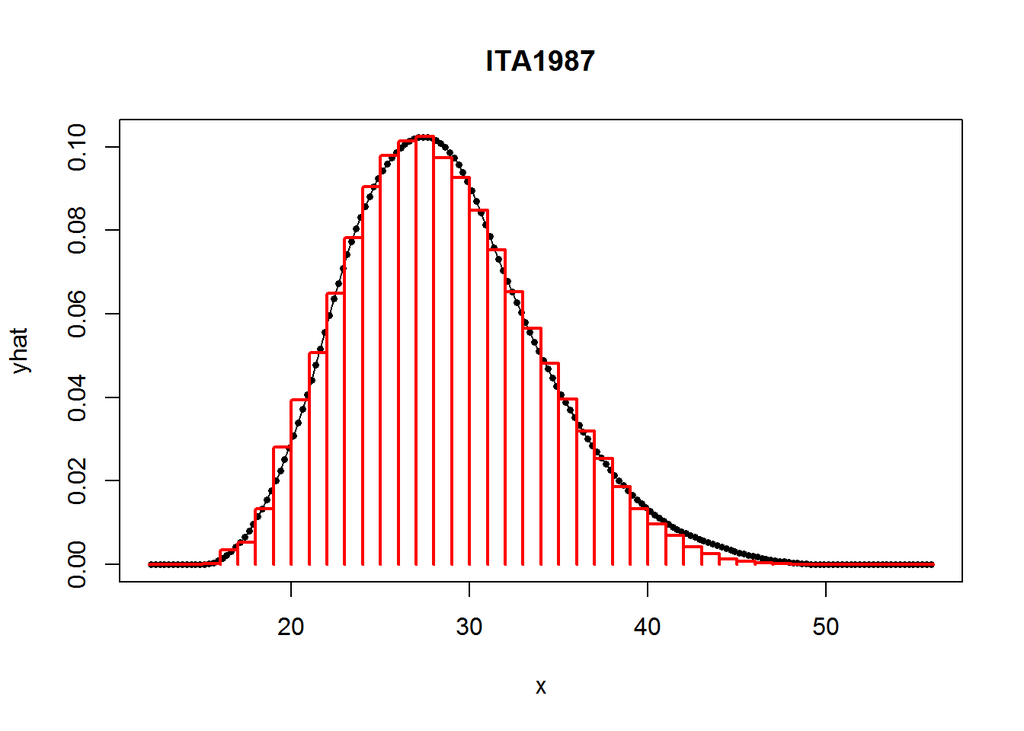

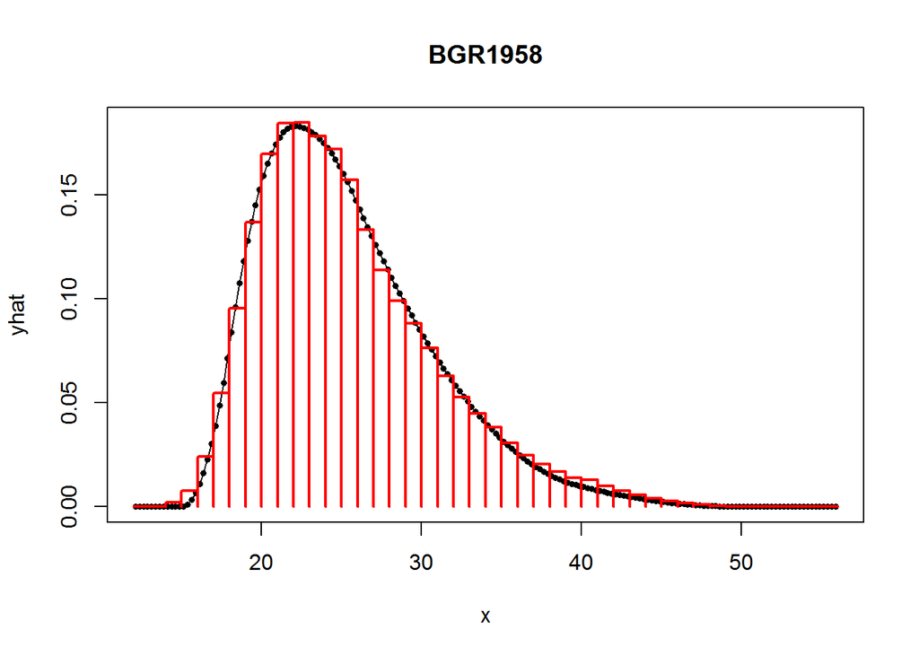

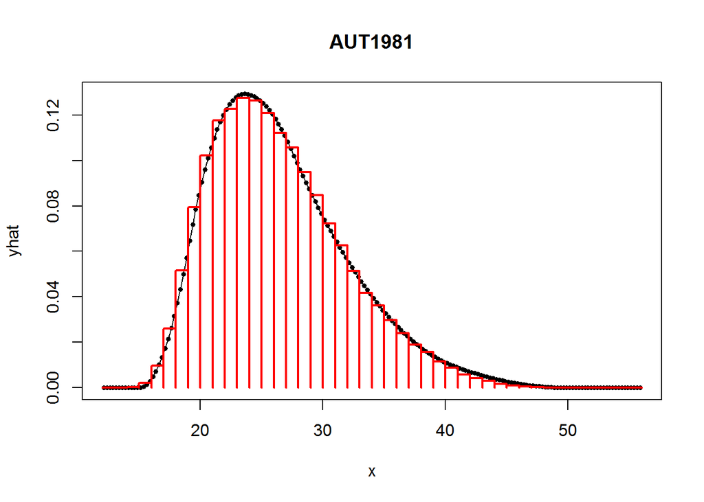

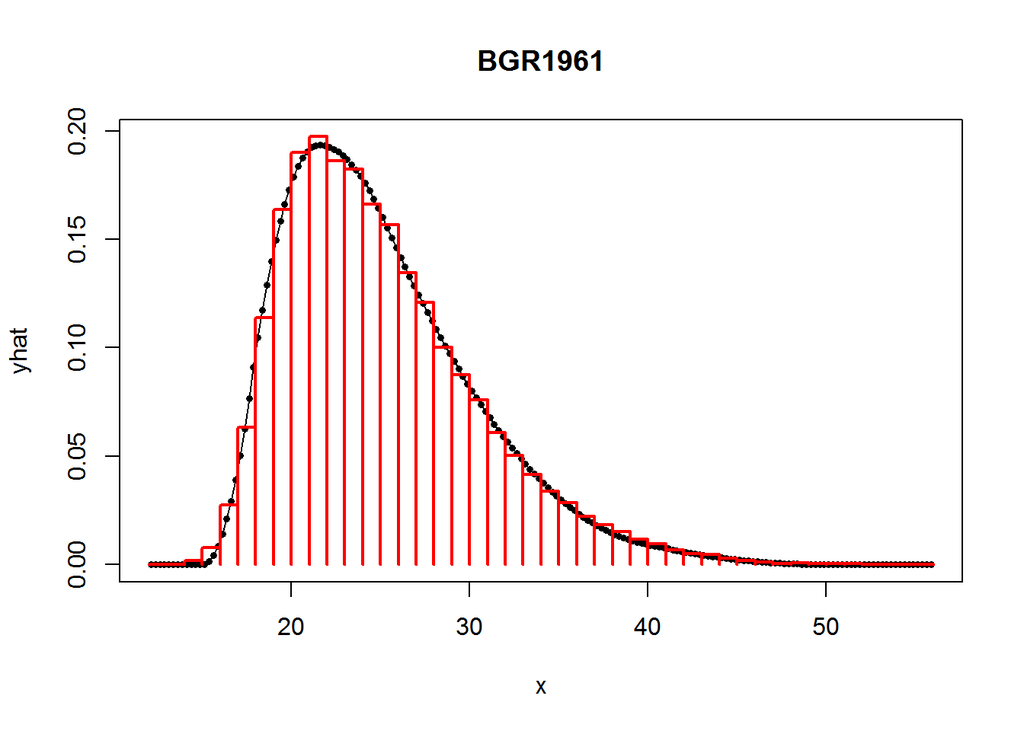

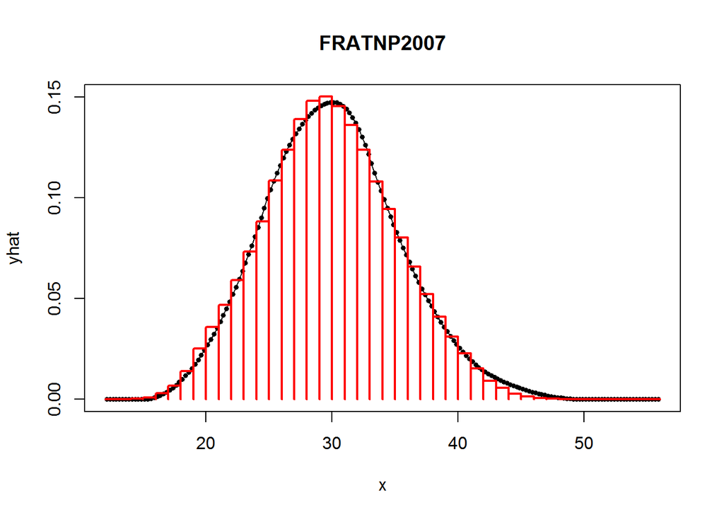

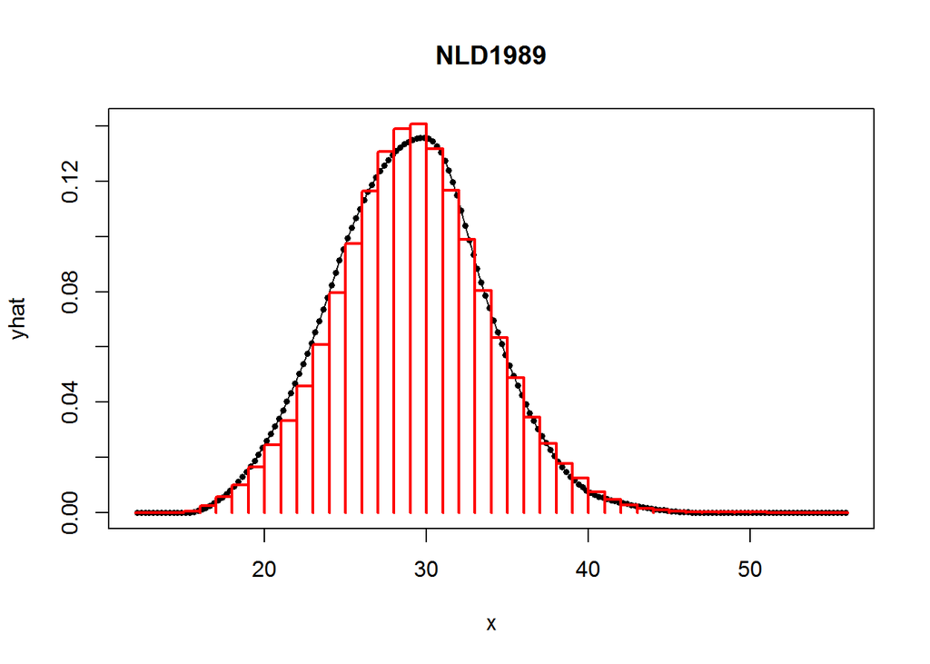

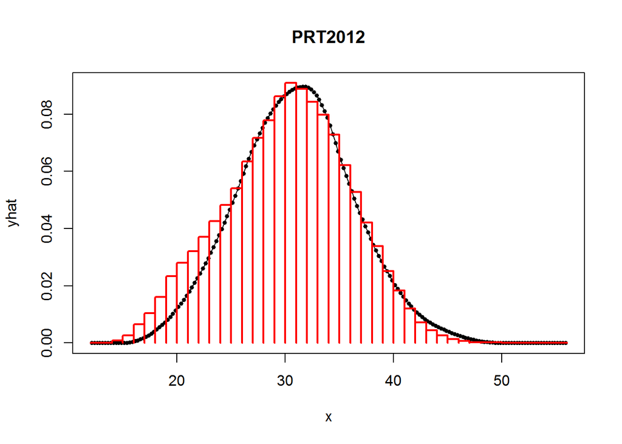

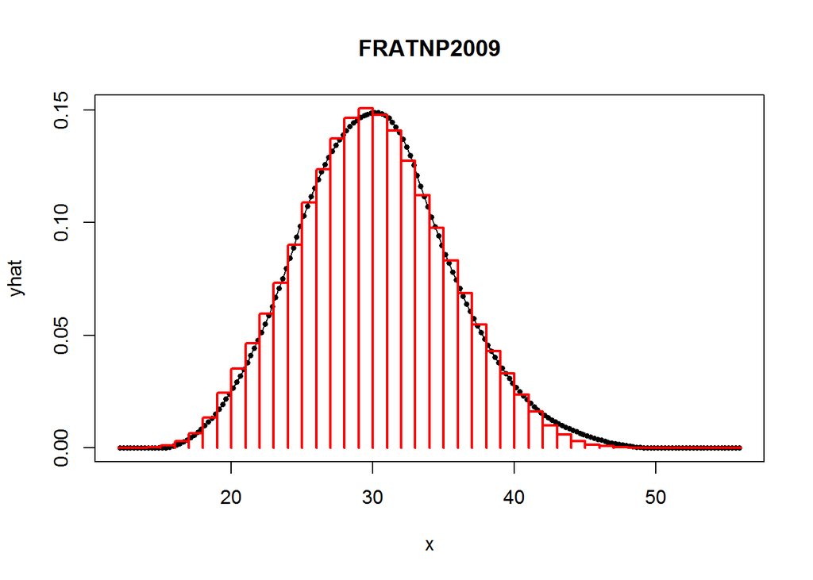

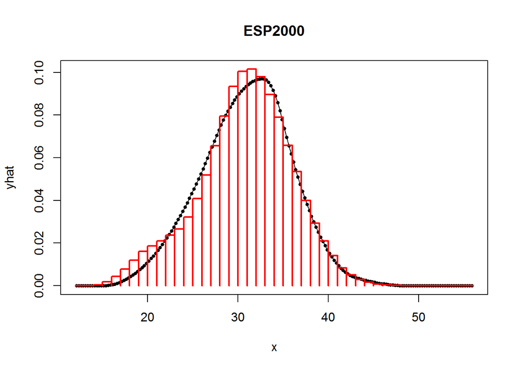

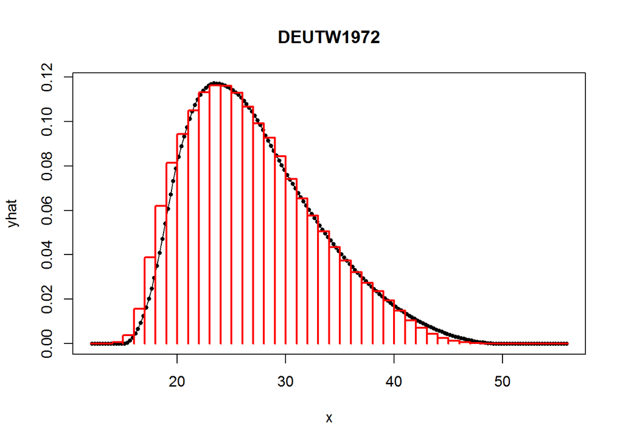

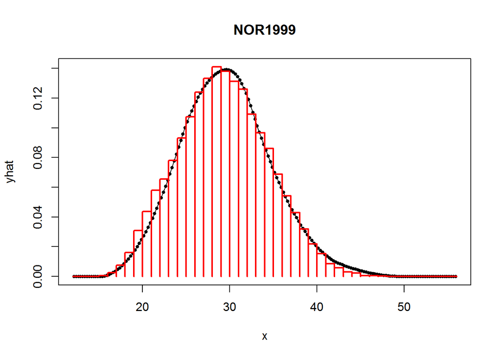

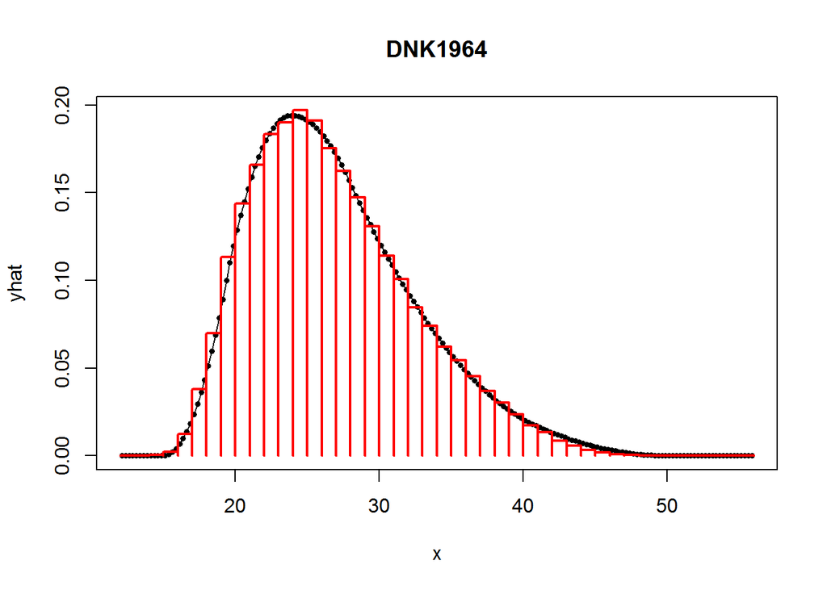

[8 more figures not shown]

```r
## define the grid of ages over which to calculuate fertility rates
delta = .25
interp_ages = seq(from=12+delta/2, to=56-delta/2, by=delta)

#####################
selected_schedules = sample( colnames(HFDmatrix), 20)

for (this_schedule in selected_schedules) {

    fx <- HFDmatrix[, this_schedule]

    ## INITIAL ESTIMATES OF PARAMETERS using MAC for P
    midage <- 12:55 + 0.5
    mac   <- sum(fx*midage)/sum(fx)
    param <- c(alpha=15,R=max(fx),P=mac, H=(mac+50)/2)

    initial.error = QS.error(param, x=interp_ages, y=fx )  # difft scales for fx5 will produce difft errors

    ## find optimal R, P & H params for QS
    this.result <- optim(par=param, fn=QS.error,
                     x=interp_ages, y=fx,
                     method="BFGS",
                     control=list(fnscale=initial.error,
                                  parscale=rep(.10,4)))

    results = rbind(results,
                    data.frame(sched  = this_schedule,
                               alpha  = round(this.result$par['alpha'],2),
                               R      = round(this.result$par['R'],3),
                               P      = round(this.result$par['P'],2),
                               H      = round(this.result$par['H'],2)
                    ))


    #-------- plot --------------
    x     = interp_ages
    fit   = QS(x=x, alpha=15, R=this.result$par['R'], P=this.result$par['P'], H=this.result$par['H'])
    yhat  = fit$y

    plot( x, yhat, type='o', main=this_schedule, pch=16, cex=.60,
          ylim=range(0,yhat,fx))

    L = seq(12,55,1)
    segments(L, fx, L+1,  fx, col=2, lwd=2)
    segments(L,     0, L  , fx, col=2, lwd=2)
    segments(L+1,   0, L+1, fx, col=2, lwd=2)

} # for this_schedule
```

## Display the parameter estimates that correspond to the graphs

```r
rownames(results) = NULL
results
```

```
##         sched alpha     R     P     H
## 1     ITA1987 14.79 0.102 27.45 33.87
## 2     BGR1958 15.03 0.183 22.06 29.41
## 3     AUT1981 14.68 0.129 23.55 31.07
## 4     BGR1961 15.15 0.193 21.50 28.91
## 5  FRATNP2007 14.69 0.147 30.13 35.73
## 6     NLD1989 16.23 0.136 29.86 34.22
## 7     PRT2012 11.83 0.090 31.74 36.95
## 8  FRATNP2009 14.61 0.149 30.26 35.88
## 9     ESP2000 14.97 0.097 32.76 36.80
## 10  DEUTW1972 13.74 0.117 23.41 32.36
## 11    NOR1999 13.87 0.139 29.69 35.16
## 12    DNK1964 14.71 0.194 23.87 31.70
## 13    CHE1961 15.73 0.182 25.95 33.94
## 14  DEUTE1991 15.82 0.098 22.43 28.08
## 15    CAN2005 12.73 0.115 30.81 35.92
## 16 DEUTNP2002 12.32 0.098 29.66 35.30
## 17    NOR1971 14.91 0.181 23.45 31.93
## 18    USA2004 11.01 0.125 26.05 35.47
## 19 FRATNP1979 15.18 0.153 24.89 31.33
## 20    NOR2008 14.00 0.146 30.59 35.98
```